# ASD_Processing_GSE50759_Final

Project Goal: to investigate whether the 94-CpG pediatric buccal clock shows a deviation in estimate in individuals effected with Autism Spectrum Disorder. Going to look at the cohort “GSE50759”

https://www.ncbi.nlm.nih.gov/geo/query/acc.cgi?acc=GSE50759 Berko ER, Suzuki M, Beren F, Lemetre C et al. Mosaic epigenetic dysregulation of ectodermal cells in autism spectrum disorder. PLoS Genet 2014;10(5):e1004402. PMID: 24875834

Notes: This analysis is separate from the GSE50759 Preprocessing because that was for selecting only typically developing <20 year old samples specifically for being part of the test dataset. From that script, we identified some samples to remove for which we will also remove in this study, not all of them, because we want to include the ASD cases.

In the test data, we only included 32 samples. However, some filtering was done PRIOR to selecting only TD cases: Started with n=96 -12 had low buccal counts -2 were “other” outliers -1 was a sex mismatch

This left me with 81 samples, which I then removed all ASD cases, this left me with 42 TD. I then removed 8 samples because they were over 20 years old, then I removed 2 samples because they did not have exact age. Left with 32 samples.

Okay, so based on previous processing of this dataset we are going to remove the following samples: -2 outliers (“7668610064_R01C02”, “7676960015_R05C02”) -1 sex mismatch (7676960039_R03C01) -8 samples over 20 years old (“6229076093_R04C02” “7668610037_R02C01” “7668610064_R02C02” “7668610064_R05C02” “7676960015_R03C02” “7676960041_R01C01” “7676960041_R03C01” “7676960040_R06C01”) -2 that did not have exact age (“7676960039_R06C01”, “7676960040_R02C02”)

In summary, going to remove 13 samples, this will leave us with 83.

```r
library(ggplot2)
library(dplyr)
library(MatchIt)
library(Rmisc)
library(robustHD)
GSE <- read.csv("~/KoborLab/kobor_space/cake/big_data/lmcewen/GSE50759_Greally/GSE50759_2017Nov/GSE50759_96FULLMETA_2017Nov1.csv") #96 smples
length(remove <- c("7668610064_R01C02", "7676960015_R05C02",   "7676960039_R03C01", "6229076093_R04C02", "7668610037_R02C01", "7668610064_R02C02", "7668610064_R05C02" ,"7676960015_R03C02", "7676960041_R01C01" ,"7676960041_R03C01" ,"7676960040_R06C01", "7676960039_R06C01", "7676960040_R02C02")) #13
```

```
## [1] 13
```

```r
length(unique(remove)) #13
```

```
## [1] 13
```

```r
GSE$barcode <- paste0(GSE$SentrixID, "_",GSE$SentrixPosition)
dim(GSE_83 <- GSE[!(GSE$barcode%in%remove),]) #n=83
```

```
## [1] 83 56
```

```r
summary(lm(ped94Age ~ Case+ FinalAge2+Buccal+SentrixID+BioSex+CEU, data = GSE_83)) #0.01168
```

```
##
## Call:
## lm(formula = ped94Age ~ Case + FinalAge2 + Buccal + SentrixID +
##     BioSex + CEU, data = GSE_83)
##
## Residuals:
##      Min       1Q   Median       3Q      Max
## -3.00089 -0.42309 -0.04083  0.57837  1.44059
##
## Coefficients:
##               Estimate Std. Error t value Pr(>|t|)
## (Intercept) -6.942e-01  1.430e+00  -0.485  0.62882
## CaseTD      -5.389e-01  2.084e-01  -2.586  0.01168 *
## FinalAge2    7.066e-01  2.310e-02  30.596  < 2e-16 ***
## Buccal       3.690e-02  1.289e-02   2.864  0.00545 **
## SentrixID   -1.026e-11  1.387e-10  -0.074  0.94126
## BioSexMale  -2.927e-01  1.975e-01  -1.482  0.14251
## CEU          4.520e-03  3.689e-03   1.225  0.22432
## ---
## Signif. codes:  0 '***' 0.001 '**' 0.01 '*' 0.05 '.' 0.1 ' ' 1
##
## Residual standard error: 0.7707 on 74 degrees of freedom
##   (2 observations deleted due to missingness)
## Multiple R-squared:  0.9452, Adjusted R-squared:  0.9408
## F-statistic: 212.8 on 6 and 74 DF,  p-value: < 2.2e-16
```

```r
#there are two individuals without ethnicity information, so the model automatically drops them. Let's remove these individuals so we can plot residuals (age accel):
dim(GSE_81 <- GSE_83[!(is.na(GSE_83$CEU)),]) #n=81
```

```
## [1] 81 56
```

```r
summary(lm(ped94Age ~ Case+ FinalAge2+Buccal+SentrixID+BioSex+CEU, data = GSE_81)) #0.01168, good good.
```

```
##
## Call:
## lm(formula = ped94Age ~ Case + FinalAge2 + Buccal + SentrixID +
##     BioSex + CEU, data = GSE_81)
##
## Residuals:
##      Min       1Q   Median       3Q      Max
## -3.00089 -0.42309 -0.04083  0.57837  1.44059
##
## Coefficients:
##               Estimate Std. Error t value Pr(>|t|)
## (Intercept) -6.942e-01  1.430e+00  -0.485  0.62882
## CaseTD      -5.389e-01  2.084e-01  -2.586  0.01168 *
## FinalAge2    7.066e-01  2.310e-02  30.596  < 2e-16 ***
## Buccal       3.690e-02  1.289e-02   2.864  0.00545 **
## SentrixID   -1.026e-11  1.387e-10  -0.074  0.94126
## BioSexMale  -2.927e-01  1.975e-01  -1.482  0.14251
## CEU          4.520e-03  3.689e-03   1.225  0.22432
## ---
## Signif. codes:  0 '***' 0.001 '**' 0.01 '*' 0.05 '.' 0.1 ' ' 1
##
## Residual standard error: 0.7707 on 74 degrees of freedom
## Multiple R-squared:  0.9452, Adjusted R-squared:  0.9408
## F-statistic: 212.8 on 6 and 74 DF,  p-value: < 2.2e-16
```

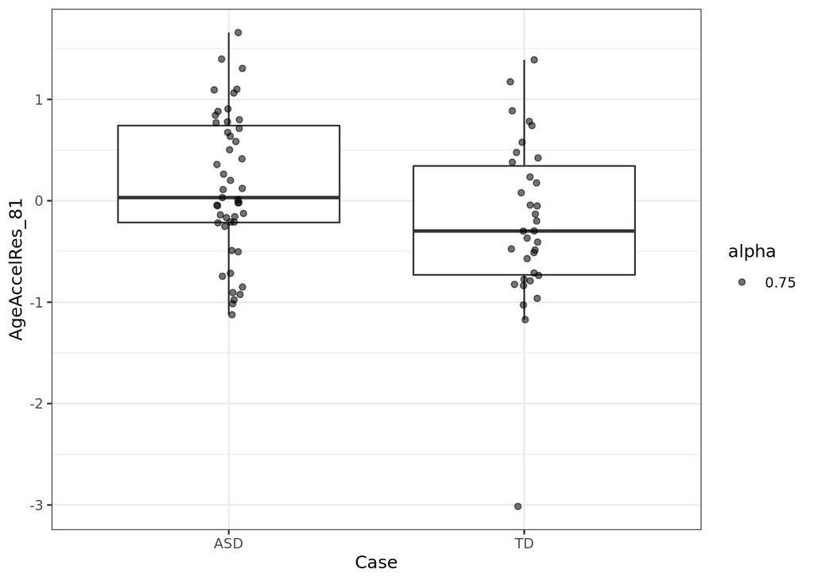

```r
GSE_81$AgeAccelRes_81 <- lm(ped94Age ~ FinalAge2+Buccal+SentrixID+BioSex+CEU, data = GSE_81)$residuals

ggplot(GSE_81, aes(Case, AgeAccelRes_81))+
        geom_boxplot(outlier.shape = NA)+
        geom_jitter(width=0.05, aes(alpha=0.75))+
        theme_bw()
```

```r
tapply(GSE_81$AgeAccelRes_81, GSE_81$Case, mean)
```

```
##        ASD         TD
##  0.1567834 -0.2167300
```

```r
# 0.1567834 -0.2167300 , ASD cases were 0.3735134 years old than TD.

range(GSE_81$FinalAge2) #1.150685 19.958904
```

```
## [1]  1.150685 19.958904
```

```r
mean(GSE_81$FinalAge2) #8.01079
```

```
## [1] 8.01079
```

```r
sd(GSE_81$FinalAge2) #4.295481
```

```
## [1] 4.295481
```

```r
table(GSE_81$Case) #ASD  TD
```

```
##
## ASD  TD
##  47  34
```

```r
table(GSE_81$BioSex) #31 Female, 50 Male (61.7284% male)
```

```
##
## Female   Male
##     31     50
```

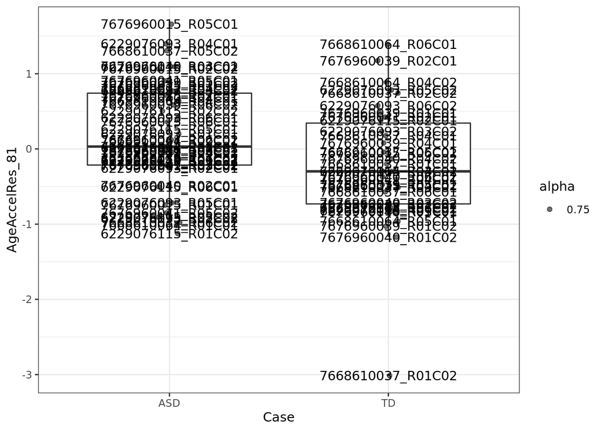

```r
#now without the outlier
ggplot(GSE_81, aes(Case, AgeAccelRes_81))+
        geom_boxplot(outlier.shape = NA)+
        geom_jitter(width=0.05, aes(alpha=0.75))+
        theme_bw()+
        geom_text(label = GSE_81$barcode)
```

```r
#outlier is 7668610037_R01C02

dim(GSE_80 <- GSE_81[!(GSE_81$barcode%in%"7668610037_R01C02"),]) #n=80
```

```
## [1] 80 57
```

```r
summary(lm(ped94Age ~ Case+ FinalAge2+Buccal+SentrixID+BioSex+CEU, data = GSE_80)) #0.00455, good good.
```

```
##
## Call:
## lm(formula = ped94Age ~ Case + FinalAge2 + Buccal + SentrixID +
##     BioSex + CEU, data = GSE_80)
##
## Residuals:
##      Min       1Q   Median       3Q      Max
## -1.62004 -0.40145 -0.01164  0.46266  1.47533
##
## Coefficients:
##               Estimate Std. Error t value Pr(>|t|)
## (Intercept)  2.511e-01  1.262e+00   0.199  0.84277
## CaseTD      -5.321e-01  1.817e-01  -2.928  0.00455 **
## FinalAge2    7.457e-01  2.164e-02  34.456  < 2e-16 ***
## Buccal       2.482e-02  1.150e-02   2.158  0.03421 *
## SentrixID   -4.648e-11  1.212e-10  -0.384  0.70246
## BioSexMale  -4.431e-01  1.749e-01  -2.534  0.01343 *
## CEU          4.675e-03  3.217e-03   1.453  0.15041
## ---
## Signif. codes:  0 '***' 0.001 '**' 0.01 '*' 0.05 '.' 0.1 ' ' 1
##
## Residual standard error: 0.672 on 73 degrees of freedom
## Multiple R-squared:  0.9575, Adjusted R-squared:  0.954
## F-statistic: 273.8 on 6 and 73 DF,  p-value: < 2.2e-16
```

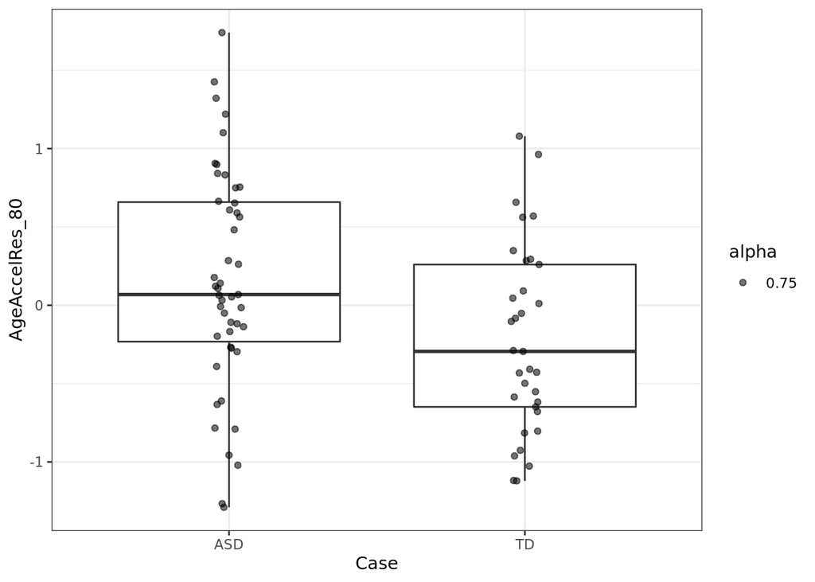

```r
GSE_80$AgeAccelRes_80 <- lm(ped94Age ~ FinalAge2+Buccal+SentrixID+BioSex+CEU, data = GSE_80)$residuals

#supp figure 2S
ggplot(GSE_80, aes(Case, AgeAccelRes_80))+
        geom_boxplot(outlier.shape = NA)+
        geom_jitter(width=0.05, aes(alpha=0.75))+
        theme_bw()
```

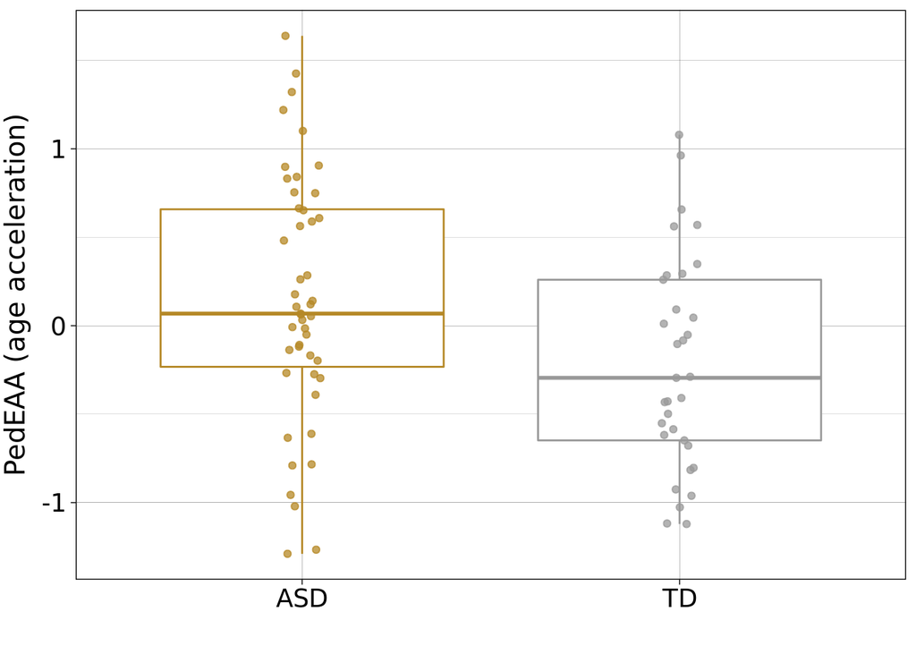

```r
#winsorize
GSE_80 <- GSE_80 %>%
  mutate(winz_ageaccel = winsorize(AgeAccelRes_80))

ggplot(GSE_80, aes(Case, winz_ageaccel, col=Case))+
        geom_boxplot(outlier.shape = NA)+
        geom_jitter(width=0.05, alpha=0.75)+
        #geom_point(alpha=0.7,size=2)+
        theme_linedraw()+
        scale_color_manual(values=c("#b58826","#999999"))+
        xlab(" ")+
        ylab("PedEAA (age acceleration)")+
     theme(axis.text.x=element_text(size=14),
      axis.text.y=element_text(size=14),
      axis.title.x=element_text(size=15, vjust=-0.3),
      axis.title.y=element_text(size=15, vjust=2),
      legend.position = "none")
```

```r
tapply(GSE_80$AgeAccelRes_80, GSE_80$Case, mean)
```

```
##        ASD         TD
##  0.1548019 -0.2204755
```

```r
tapply(GSE_80$AgeAccelRes_80, GSE_80$Case, sd)
```

```
##       ASD        TD
## 0.7016507 0.5984478
```

```r
CI(GSE_80$AgeAccelRes_80)
```

```
##         upper          mean         lower
##  1.519626e-01 -2.911964e-17 -1.519626e-01
```

# now propensity score matching

```r
GSE_81 <- droplevels(GSE_81)

#look into sibship stuff - family ID is repeated for individuals, operating under the assumption that multiple people for same family...
GSE_81$Family <-  gsub("_.*$","",GSE_81$source_name_ch1)
GSE_81$Family <- as.factor(GSE_81$Family)
GSE_81$Case1 <- gsub("2","0",as.numeric(as.factor(GSE_81$Case)))
GSE_81_sub1 <- GSE_81[,c("Case1","ped94Age", "FinalAge2", "Buccal", "SentrixID", "BioSex", "CEU")]
GSE_81_sub2 <- GSE_81_sub1[complete.cases(GSE_81_sub1),]
dim(GSE_81_sub2) #81,8
MATCH_out <- matchit(Case1 ~ FinalAge2+Buccal+SentrixID+BioSex+CEU,
                      method="nearest", distance="logit", discard="both",
                      ratio=2, caliper=.25,order="largest",data = GSE_81_sub2)
sum_match <- summary(MATCH_out, interactions=T, standardize=T)
sum_match  ### only 22 and 17 matched
wt <- MATCH_out$weights
GSE_81_match_data <- GSE_81_sub2[wt>0,]
dim(GSE_81_match_data) #39, 8
summary(lm(ped94Age ~ Case+FinalAge2+Buccal+SentrixID+BioSex+CEU, data = GSE_81)) #p=0.01168
summary(lm(ped94Age ~ Case1+FinalAge2+Buccal+SentrixID+BioSex+CEU, data = GSE_81_match_data)) #0.03, can't add family as a covariate because too many levels: "ALL 37 residuals are 0: no residual degrees of freedom!”"

GSE_81_match_data$AgeAccelRes_Matched_Corrected <- summary(lm(ped94Age ~ FinalAge2+Buccal+SentrixID+BioSex+CEU, data = GSE_81_match_data))$residuals
#need to change 0 and 1 to ASD and TD, respectively because it plots naturally with 1 on the right but we want ASD on the left for consistency
#CASE: 1 = ASD, 0 = TD
GSE_81_match_data$Case2 <- gsub("1","ASD", GSE_81_match_data$Case1)
GSE_81_match_data$Case2 <- gsub("0","TD", GSE_81_match_data$Case2)
GSE_81_match_data$Case2 <- as.factor(GSE_81_match_data$Case2)
ggplot(GSE_81_match_data, aes(Case2, AgeAccelRes_Matched_Corrected))+
        geom_boxplot()+
        geom_point()


#Couldn't correct for family because too few degrees of freedom. Going to ONLY look at family members, are they evenly distributed in ASD vs TD?
library(dplyr)
GSE_sibs <- GSE_81 %>%
group_by(Family) %>%
  filter(n()>1)
dim(GSE_sibs)#25 "families"
GSE_sibs$AgeAccelRes_SIB <-  lm(ped94Age ~ FinalAge2+Buccal+SentrixID+BioSex+CEU, data = GSE_sibs)$residuals
GSE_sibs <- as.data.frame(GSE_sibs)
ggplot(GSE_sibs, aes(Case, AgeAccelRes_SIB, color = Family))+
        geom_point()+
        geom_text(aes(label=as.character(GSE_sibs$Family)))

#Looks like most of the family members are TD, only 4 paired between ASD + TD, and the rest are all TD family members. Going to take OUT all family members to see if patterns persist…

GSE_67_nosibs <- GSE_81[!duplicated(GSE_81$Family),]
GSE_67_nosibs$Family <- droplevels(GSE_67_nosibs$Family)
table(GSE_67_nosibs$Family) #all single families now
summary(lm(ped94Age ~ Case1 +FinalAge2+Buccal+SentrixID+BioSex+CEU, data = GSE_67_nosibs)) #p= 0.03395, the pattern remains, therefore I don't think family has anything to do with this
summary(lm(ped94Age ~ Case1 + FinalAge2+Buccal+SentrixID+BioSex+CEU, data = GSE_67_nosibs)) #0.03395
table(GSE_67_nosibs$Case) #47, 21
GSE_67_nosibs$AgeAccelRes_NOSIB <-  lm(ped94Age ~ FinalAge2+Buccal+SentrixID+BioSex+CEU, data = GSE_67_nosibs)$residuals
ggplot(GSE_67_nosibs, aes(Case, AgeAccelRes_NOSIB))+
        geom_boxplot()+
        geom_point()


#now do propensity score matching on data without sibs:
GSE_67_nosibs_sub1 <- GSE_67_nosibs[,c("Case1","ped94Age", "FinalAge2", "Buccal", "SentrixID", "BioSex", "CEU")]
GSE_67_nosibs_sub2 <- GSE_67_nosibs_sub1[complete.cases(GSE_67_nosibs_sub1),]
dim(GSE_67_nosibs_sub2) #68

MATCH_out <- matchit(Case1 ~ FinalAge2+Buccal+SentrixID+BioSex+CEU,
                      method="nearest", distance="logit", discard="both",
                      ratio=2, caliper=.25,order="largest",data = GSE_67_nosibs_sub2)
sum_match <- summary(MATCH_out, interactions=T, standardize=T)
sum_match  ### only 16 and 12 matched
wt <- MATCH_out$weights
GSE_nosibs_match_data <- GSE_67_nosibs_sub2[wt>0,]
dim(GSE_nosibs_match_data) #28
summary(lm(ped94Age ~ Case1+FinalAge2+Buccal+SentrixID+BioSex, data = GSE_nosibs_match_data)) #0.0338
summary(lm(ped94Age ~ Case1+FinalAge2+Buccal+SentrixID+BioSex+CEU, data = GSE_nosibs_match_data)) #0.0369
GSE_nosibs_match_data$AgeAccel_nosibs_match  <- lm(ped94Age ~ FinalAge2+Buccal+SentrixID+BioSex+CEU, data = GSE_nosibs_match_data)$residuals
GSE_nosibs_match_data$Case2 <- gsub("0","TD",GSE_nosibs_match_data$Case1)
GSE_nosibs_match_data$Case2 <- gsub("1","ASD",GSE_nosibs_match_data$Case2)
ggplot(GSE_nosibs_match_data, aes(Case2, AgeAccel_nosibs_match))+
        geom_boxplot()+
        geom_point()
```